# POLS 3316: Kat’s Project

1. import data?
2. parsing txt/csv data: I have below, a vector of 53 colors for each state and territory in my data set.

The function createdf() take in as parameters -> the data frame to be used, what variable I want to be used as a factor, in this case I use states names, and years. I then plot the data with a legend with colors associated with each state. Whatever I pass in to be used as a factor will be what populates the legend.

Before I can pass any parameters to my createdf function, I must retrieve the data first. I use as data frame to read my csv file and create a data frame from it. I then list the names which will tell me the column names to use when accessing the frame using $ character.

after passing all the information in lines 60-75, I then make a separate plot looking at the relationship between poverty + enrollment. **note, first createdf is to be ignored, is there to set size of graphic.

at the end of this R chunk, I find the mean, median, and standard deviation of poverty and enrollment gorss numbers.

```r
myColors = c( "#FFBF00", "#9966CC", "#FBCEB1", "#7FFFD4", "#007FFF", "#89CFF0", "#CB4154", "#000000", "#0000FF", "#0095B6", "#CD7F32", "#993300", "#800020", "#702963", "#DE3163", "#7FFF00", "#6F4E37", "#FF7F50", "#00FFFF", "#50C878", "#00FF3F", "#FFD700", "#BEBEBE", "#008001", "#4B0082", "#29AB87", "#C8A2C8", "#FF00FF", "#FF00AF", "#800000", "#E0B0FF", "#000080", "#CC7722", "#808000", "#FF6600", "#FF4500", "#DA70D6", "#FFE5B4", "#CCCCFF", "#FFC0CB", "#8E4585", "#003153", "#CC8899", "#6A0DAD", "#E30B5C", "#FF0000", "#C71585", "#FA8072", "#92000A", "#0F52BA", "#C0C0C0", "#708090", "#00FF7F" )

createdf <- function(myData, myFactor, col1, Year, myColors, t, yl){
  myFactor = factor(myFactor)
  levels(myData$myFactor)
  newx <- seq(min(Year), max(col1), length.out = 520)
  mymod <- lm(col1 ~ Year)
  predic <- predict(mymod, newdata = data.frame(x=newx), interval = 'confidence', level = .95)

  with(myData, plot(Year, col1, col = myColors[myFactor], ylab = yl))
  op <- par(cex = 0.37)
  with(myData, legend('topleft', legend = levels(myFactor), col = myColors, pch=1, title = "States"))
  title(t)
  abline(mymod)
  lines(newx, predic[,3], lty = 'dashed', col = 'blue')
  lines(newx, predic[ ,2], lty = 'dashed', col = 'red')

}

population_data <- as.data.frame(read.csv(file = "population.csv", header = TRUE, sep=","))
names(population_data)
```

```
[1] "Population"     "S1701_C01_001E" "Year"
```

```r
poverty_data <- as.data.frame(read.csv( file = "poverty.csv", header = TRUE, sep = ","))
names(poverty_data)
```

```
[1] "Poverty"        "S1701_C02_001E" "Year"
```

```r
enroll_data <- as.data.frame(read.csv(file = "enrollment.csv", header = TRUE, sep = ","))
names(enroll_data)
```

```
[1] "Enrollment"     "S1401_C01_001E" "Year"
```

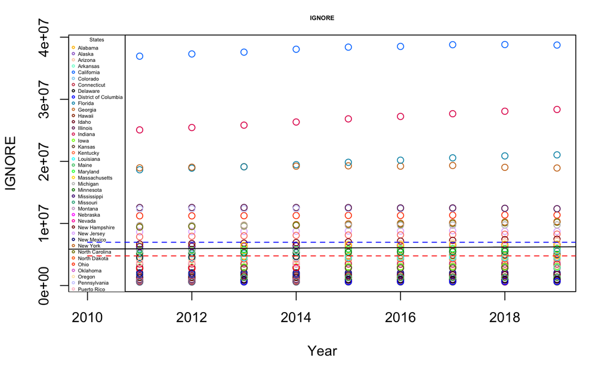

```r
# to set graphic size
dev.new(width=300,height=850, unit = "px", noRStudioGD = TRUE)

#ignore this first call, i used it to resize the following windows.
createdf(population_data, population_data$Population, population_data$S1701_C01_001E, population_data$Year, myColors, "IGNORE", "IGNORE")
```

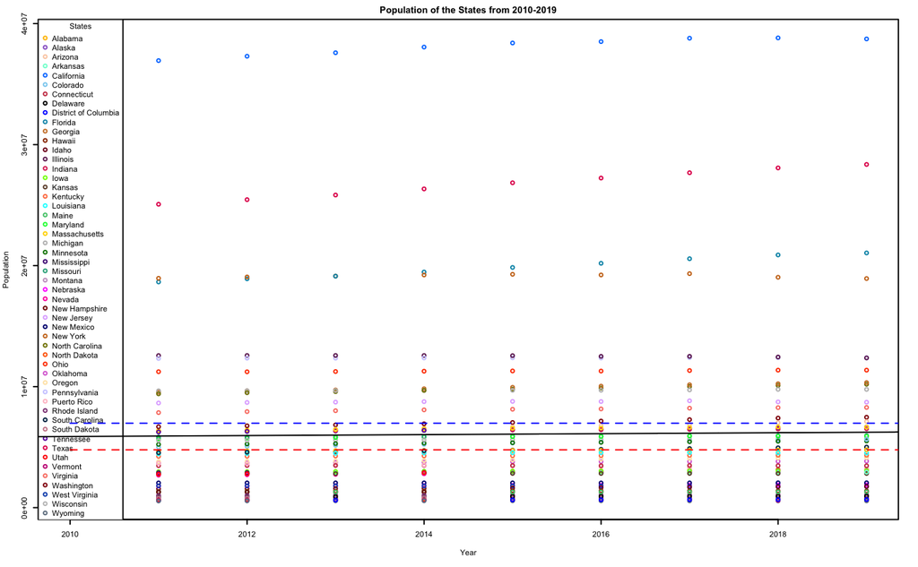

```r
# color coded plots for each respectively.
createdf(population_data, population_data$Population, population_data$S1701_C01_001E, population_data$Year, myColors, "Population of the States from 2010-2019", "Population")
```

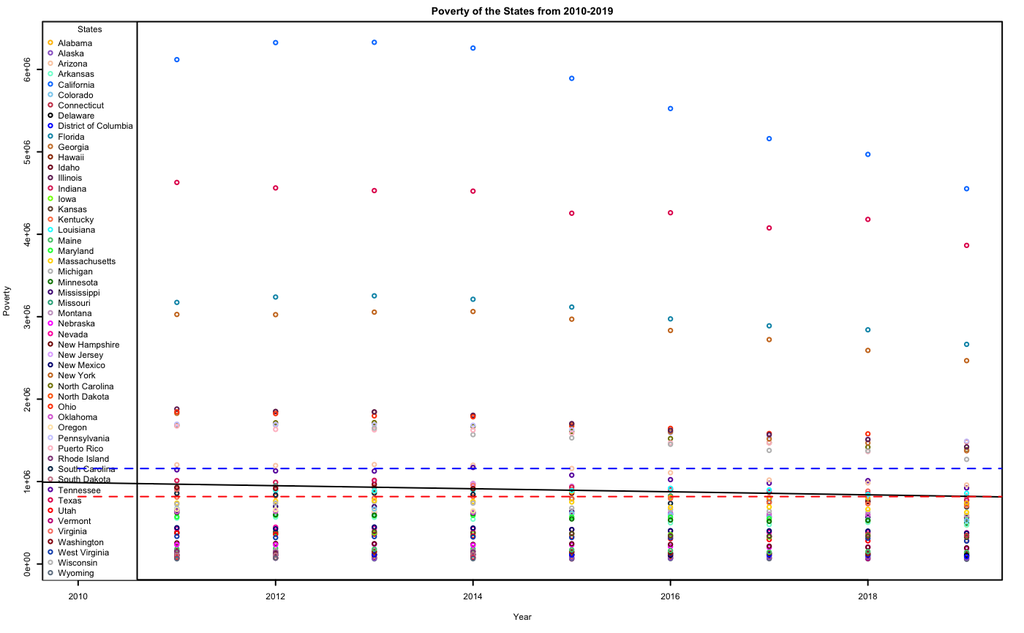

```r
createdf(poverty_data, poverty_data$Poverty, poverty_data$S1701_C02_001E, poverty_data$Year, myColors, "Poverty of the States from 2010-2019", "Poverty")
```

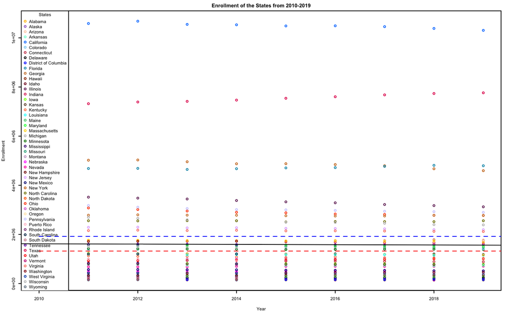

```r
createdf(enroll_data, enroll_data$Enrollment, enroll_data$S1401_C01_001E, enroll_data$Year, myColors, "Enrollment of the States from 2010-2019", "Enrollment")
```

```r
# ---------------------------------------------------------------------------------------------------- #
                  #table looking at relationship between enrollment and poverty
theFactor = factor(poverty_data$Year)
levels(poverty_data$theFactor)
```

```r
newx <- seq(min(enroll_data$S1401_C01_001E), max(poverty_data$S1701_C02_001E), length.out = 520)
mymod <- lm(poverty_data$S1701_C02_001E ~ enroll_data$S1401_C01_001E)
predic <- predict(mymod, newdata = data.frame(x=newx), interval = 'confidence', level = .95)

plot(enroll_data$S1401_C01_001E, poverty_data$S1701_C02_001E, col = myColors[theFactor], ylab = "Poverty", xlab = "Enrollment")
legend("topleft", legend = levels(theFactor), col = myColors, pch=1, title = "years")
```

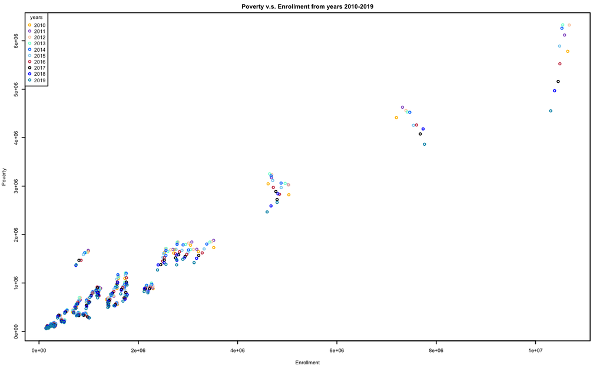

```r
title("Poverty v.s. Enrollment from years 2010-2019")
```

```r
#abline(mymod)
#lines(newx, predic[,3], lty = 'dashed', col = 'blue')
#lines(newx, predic[ ,2], lty = 'dashed', col = 'red')
# ---------------------------------------------------------------------------------------------------- #

#mean median and sd for poverty and enrollment
mean(poverty_data$S1701_C02_001E)
```

```
[1] 904380.2
```

```r
median(poverty_data$S1701_C02_001E)
```

```
[1] 618493.5
```

```r
sd(poverty_data$S1701_C02_001E)
```

```
[1] 1063883
```

```r
mean(enroll_data$S1401_C01_001E)
```

```
[1] 1592532
```

```r
median(enroll_data$S1401_C01_001E)
```

```
[1] 1025499
```

```r
sd(enroll_data$S1401_C01_001E)
```

```
[1] 1861466
```

3. more about my data, histograms

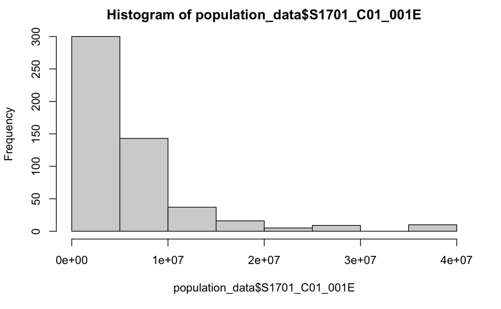

```r
#?plot
#?hist

hist(population_data$S1701_C01_001E)
```

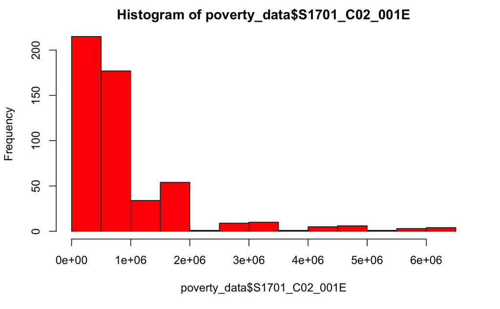

```r
hist(poverty_data$S1701_C02_001E, col = "red")
```

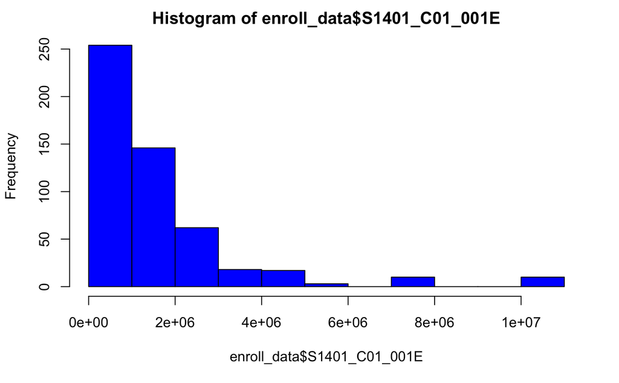

```r
hist(enroll_data$S1401_C01_001E, col = "blue")
```

```r
NA
NA
NA
```

4. The summary of my data, includes lm regression, t test, and stargazer formated table for easy viewing. ignore warning, does not apply to my table.

```r
library(stargazer)

summary(lm(population_data$S1701_C01_001E ~ population_data$Year))
```

```
Call:
lm(formula = population_data$S1701_C01_001E ~ population_data$Year)

Residuals:
     Min       1Q   Median       3Q      Max
-5677216 -4393898 -2000654   777870 32633012

Coefficients:
                      Estimate Std. Error t value Pr(>|t|)
(Intercept)          -75255521  211361211  -0.356    0.722
population_data$Year     40365     104920   0.385    0.701

Residual standard error: 6872000 on 518 degrees of freedom
Multiple R-squared:  0.0002856, Adjusted R-squared:  -0.001644
F-statistic: 0.148 on 1 and 518 DF,  p-value: 0.7006
```

```r
summary(lm(poverty_data$S1701_C02_001E ~ poverty_data$Year))
```

```
Call:
lm(formula = poverty_data$S1701_C02_001E ~ poverty_data$Year)

Residuals:
    Min      1Q  Median      3Q     Max
-926373 -667724 -289198   87509 5396587

Coefficients:
                  Estimate Std. Error t value Pr(>|t|)
(Intercept)       38315818   32711780   1.171    0.242
poverty_data$Year   -18571      16238  -1.144    0.253

Residual standard error: 1064000 on 518 degrees of freedom
Multiple R-squared:  0.002519,  Adjusted R-squared:  0.0005931
F-statistic: 1.308 on 1 and 518 DF,  p-value: 0.2533
```

```r
summary(lm(enroll_data$S1401_C01_001E ~ enroll_data$Year))
```

```
Call:
lm(formula = enroll_data$S1401_C01_001E ~ enroll_data$Year)

Residuals:
     Min       1Q   Median       3Q      Max
-1478389 -1177206  -545710   156183  9070279

Coefficients:
                 Estimate Std. Error t value Pr(>|t|)
(Intercept)      14034296   57305106   0.245    0.807
enroll_data$Year    -6176      28446  -0.217    0.828

Residual standard error: 1863000 on 518 degrees of freedom
Multiple R-squared:  9.099e-05, Adjusted R-squared:  -0.001839
F-statistic: 0.04714 on 1 and 518 DF,  p-value: 0.8282
```

```r
summary(lm(enroll_data$S1401_C01_001E ~ poverty_data$S1701_C02_001E))
```

```
Call:
lm(formula = enroll_data$S1401_C01_001E ~ poverty_data$S1701_C02_001E)

Residuals:
     Min       1Q   Median       3Q      Max
-1913887  -182921    -9625   167184  2484877

Coefficients:
                             Estimate Std. Error t value Pr(>|t|)
(Intercept)                 4.865e+04  2.352e+04   2.068   0.0391 *
poverty_data$S1701_C02_001E 1.707e+00  1.686e-02 101.282   <2e-16 ***
---
Signif. codes:  0 ‘***’ 0.001 ‘**’ 0.01 ‘*’ 0.05 ‘.’ 0.1 ‘ ’ 1

Residual standard error: 408500 on 518 degrees of freedom
Multiple R-squared:  0.9519,    Adjusted R-squared:  0.9518
F-statistic: 1.026e+04 on 1 and 518 DF,  p-value: < 2.2e-16
```

```r
model1 <- lm(enroll_data$S1401_C01_001E ~ poverty_data$S1701_C02_001E + enroll_data$Year + population_data$S1701_C01_001E)
t.test(enroll_data$S1401_C01_001E, poverty_data$S1701_C02_001E, var.equal = TRUE)
```

```
    Two Sample t-test

data:  enroll_data$S1401_C01_001E and poverty_data$S1701_C02_001E
t = 7.319, df = 1038, p-value = 4.996e-13
alternative hypothesis: true difference in means is not equal to 0
95 percent confidence interval:
 503656.7 872647.8
sample estimates:
mean of x mean of y
1592532.5  904380.2
```

```r
stargazer(model1, type="text")
```

```
===============================================
                        Dependent variable:
                    ---------------------------
                          S1401_C01_001E
-----------------------------------------------
S1701_C02_001E               0.144***
                              (0.025)

Year                      -13,527.780***
                            (2,163.364)

S1701_C01_001E               0.249***
                              (0.004)

Constant                 27,207,555.000***
                          (4,357,946.000)

-----------------------------------------------
Observations                    520
R2                             0.995
Adjusted R2                    0.995
Residual Std. Error   135,654.200 (df = 516)
F Statistic         32,403.400*** (df = 3; 516)
===============================================
Note:               *p<0.1; **p<0.05; ***p<0.01
```

```r
#?cbind

#remember to use quantile(enroll_gross)
#and to get specific regions: quantile(x, 0.25)
```

http://kat-hernandez.info/

extra code:

```r
#names <- c("southwark & Vauxhall(A)", "Lambeth(B)")
# observed
deaths_C <- c(1262, 97)
notdeaths_D <- c(38785, 26010)
AC_BC <- c()
AD_BD <- c()
k <- 0

pre_chi <- function(a, b, AC_BC, AD_BD, k){
  k <- sum(a) + sum(b)
  print("sample size:")
  print(k)
  for (i in 1:length(a)) {
    Trow <- a[i] + b[i]
    Tcol <- sum(a)
    ev <- (Trow * Tcol) / k
    AC_BC[i] <- ev
    print("AC_BC")
    print(ev)
  }
  for (i in 1:length(b)) {
    Trow <- a[i] + b[i]
    Tcol <- sum(b)
    ev <- (Trow * Tcol) / k
    AD_BD[i] <- ev
    print("AD_BD")
    print(ev)
  }
  result <- c(k, AC_BC, AD_BD)
  temp3 = 0
  for (i in 1:length(a)) {
    temp1 <- ( ((a[i] - AC_BC[i])^2) / AC_BC[i] )
    temp2 <- ( ((b[i] - AD_BD[i])^2) / AD_BD[i] )
    temp3 <- temp3 + temp1 + temp2
  }
  print("chi score?")
  print(temp3)
  return(result)
}

# ------ call for pre-chi -------- #
#result <- pre_chi(deaths_C, notdeaths_D, AC_BC, AD_BD, k)
#result # contains: k, AC, BC ; AD, BD

rep <- c(25, 50)
dem <- c(35, 10)
result <- pre_chi(rep, dem, AC_BC, AD_BD, k)
```

```
[1] "sample size:"
[1] 120
[1] "AC_BC"
[1] 37.5
[1] "AC_BC"
[1] 37.5
[1] "AD_BD"
[1] 22.5
[1] "AD_BD"
[1] 22.5
[1] "chi score?"
[1] 22.22222
```

```r
# next problem
# observed
groupA <- c(47.68, 48.02, 51.11, 50.50, 48.69, 51.12, 50.24, 48.49, 48.4)
groupB <- c(48.89, 48.77, 49.76, 51.71, 49.44, 49.77, 51.45, 49.24, 47.05)
# expected
gA <- c()
gB <- c()
# sample size
k <- 0
# pre_chi function call ; result contains all values found.
#result <- pre_chi(groupA, groupB, gA, gB, k)
```

extra code:

```r
deaths_C <- c(1262, 97)
notdeaths_D <- c(38785, 26010)

# sample size
kt <- sum(deaths_C) + sum(notdeaths_D)
#kt
# observed
dO <- c()
nO <- c()

for (i in 1:length(deaths_C)) {
  Trow <- notdeaths_D[i] + deaths_C[i]
  Tcol <- sum(deaths_C)
  ev <- (Trow * Tcol) / kt
  dO[i] <- ev
}
for (i in 1:length(notdeaths_D)) {
  Trow <- notdeaths_D[i] + deaths_C[i]
  Tcol <- sum(notdeaths_D)
  ev <- (Trow * Tcol) / kt
  nO[i] <- ev
}
#prints like : AB, BC ; AD, BD -> when called like : deaths then not deaths
#dO
#nO


# other group a and b
myvec <- c()
names <- c("group A", "group B")
# observed
groupA <- c(47.68, 48.02, 51.11, 50.50, 48.69, 51.12, 50.24, 48.49, 48.4)
groupB <- c(48.89, 48.77, 49.76, 51.71, 49.44, 49.77, 51.45, 49.24, 47.05)
# finds sample size
k <- sum(groupA) + sum(groupB)
#k
# expected
gA <- c()
gB <- c()
for (i in 1:length(groupA)) {
  Trow <- groupA[i] + groupB[i]
  Tcol <- sum(groupA)
  ev <- (Trow * Tcol) / k
  gA[i] = ev
}
for (i in 1:length(groupB)) {
  Trow <- groupB[i] + groupA[i]
  Tcol <- sum(groupB)
  ev <- (Trow * Tcol)/k
  gB[i] <- ev
}
#gA
#gB


for (i in 1:length(groupA)) {
  temp <- ((groupA[i] + groupB[i])^2 )/ k
  #print(temp)
  myvec[i] = temp
}
themean <-mean(myvec)
thesd <-sd(myvec)
temp2 <- 0
for (i in 1:length(groupA)) {
  temp2 <- temp2 + (groupA[i] - themean)^2
}
#print(temp2/ (thesd)^2)

#mydf <- data.frame(groupA, groupB)
#mydf <- data.frame(rep, dem)
# find expexted values

#mydf
#chisq.test(mydf$groupA, mydf$groupB, correct = FALSE)
#?t.test
before <- c(49.9, 50.1, 46.5, 48.4, 54.1, 54.2, 48.8, 48.7)
after <- c(48.0, 46.3, 47.2, 43.0, 46.0, 47.7, 43.6, 45.0)

#for (i in 1:length(before)) {
 # temp <- ((before[i] + groupB[i])^2 )/ k
  #print(temp)
 # myvec[i] = temp
#}
#themean <-mean(myvec)
#thesd <-sd(myvec)
#temp2 <- 0
for (i in 1:length(before)) {
  temp2 <- temp2 + (after[i] - before[i])^2
  #temp2 <- temp2 + (after[i] - (-4.2375) )^2
}
myx <- sum(before) + sum(after)
print(temp2/ 7)
```

```
[1] 1922.403
```

```r
mydf <- data.frame(before, after)
t.test(mydf$after, mydf$before, paired = TRUE)
```

```
    Paired t-test

data:  mydf$after and mydf$before
t = -4.3707, df = 7, p-value = 0.003271
alternative hypothesis: true mean difference is not equal to 0
95 percent confidence interval:
 -6.530061 -1.944939
sample estimates:
mean difference
        -4.2375
```

```r
?qt
qt(0.05, 8)
```

```
[1] -1.859548
```